# R Notebook

## Load in required packages

First let’s load in the packages that we’ll use in our analysis. These packages provide us with tools and additional functionality that will make it easier to conduct our analysis.

```r
library(tidyverse)
library(tigris)
library(leaflet)
library(sf)
```

## Load in dataset

Today we are going to use data on lead (Pb) in drinking water in New York State schools. The data is from the New York State Department of Health and can be [accessed here](https://health.data.ny.gov/Health/Lead-Testing-in-School-Drinking-Water-Sampling-and/rkyy-fsv9). We’ve also added some additional data (income and racial/ethnic breakdown of the population) from the US Census Bureau.

Now let’s load in the data that we will use in our analysis.

The code below loads in a **csv** file (essentially an Excel file) with the data and converts it into a data table in R.

```r
Pb_data <- read_csv("https://github.com/stahlm/Hackathon_2020/raw/master/data/Lead_schools_hackathon_dataset.csv")
```

In the above code the function `read_csv()` reads in the specified file and then assigns it to a data object that we are calling `Pb_data`. Note that the `<-` is essentially acting as an equals sign.

## Let’s take a look at the data

Before we do any analysis we should take a look at the data to make sure it loaded in correctly and that we understand the general contents of the dataset. The `head()` function allows us to preview the first few rows of the dataset.

```r
head(Pb_data)
```

| School | Type_of_Organization | County | School_District | School_City | School_Zip_Code | School_Street | Number_of_Outlets_LT_15_ppb | Number_of_Outlets_GT_15_ppb | Any_Buildings_with_Lead_Free_Plumbing | Out_of_Service | Latitude | Longitude | Median_HH_income | County_population | County_White | County_Black_AfAm | County_Asian | County_Hispanic_Latino |
| --- | --- | --- | --- | --- | --- | --- | --- | --- | --- | --- | --- | --- | --- | --- | --- | --- | --- | --- |
| SULLIVAN BOCES | BOCES School | Sullivan | BOCES No District Name | LIBERTY | 12754 | 6 WIERK AVE | NA | NA | No | No | 41.70517 | -74.71170 | 41861 | 77547 | 57780 | 6349 | 1033 | 10554 |
| HAMBURG SHS | Public School | Erie | HAMBURG CENTRAL SCHOOL | HAMBURG | 14075 | LEGION DR | 98 | 6 | No | Yes | 42.88814 | -78.79554 | 63478 | 919040 | 714156 | 119916 | 23621 | 41731 |
| LYONS ELEMENTARY SCHOOL | Public School | Wayne | LYONS CENTRAL SCHOOL | LYONS | 14489 | 98 WILLIAMS ST | 27 | 2 | No | Yes | 43.14434 | -77.11799 | 42088 | 93772 | 85318 | 2743 | 465 | 3476 |
| OAK ORCHARD SCHOOL | Public School | Orleans | MEDINA CENTRAL SCHOOL | MEDINA | 14103 | W OAK ORCHARD ST | 110 | 5 | No | Yes | 43.24839 | -78.21844 | 43391 | 42883 | 37658 | 2368 | 173 | 1757 |
| BRADLEY ELEMENTARY SCHOOL | Public School | Oneida | NEW HARTFORD CENTRAL SCHOOL | NEW HARTFORD | 13413 | OXFORD RD | 97 | 0 | No | No | 43.14948 | -75.36177 | 64146 | 234878 | 199254 | 13682 | 6522 | 10819 |
| COLDEN ES | Public School | Erie | SPRINGVILLE-GRIFF INST CENTRAL SCHOOL | COLDEN | 14033 | COLDEN ES | 55 | 6 | No | Yes | 42.88814 | -78.79554 | 78750 | 919040 | 714156 | 119916 | 23621 | 41731 |

You can see that each of the columns stores a variable (e.g. School, County,…) and each row stores an observation (i.e. data on an individual school).

We can also get some basic info and statistics for each of the columns (variables) by using the `summary()` function.

```r
summary(Pb_data)
```

```
    School          Type_of_Organization    County          School_District    School_City        School_Zip_Code
 Length:4682        Length:4682          Length:4682        Length:4682        Length:4682        Min.   : 6390
 Class :character   Class :character     Class :character   Class :character   Class :character   1st Qu.:11106
 Mode  :character   Mode  :character     Mode  :character   Mode  :character   Mode  :character   Median :11741
                                                                                                  Mean   :12132
                                                                                                  3rd Qu.:13316
                                                                                                  Max.   :14905
                                                                                                  NA's   :20
 School_Street      Number_of_Outlets_LT_15_ppb Number_of_Outlets_GT_15_ppb Any_Buildings_with_Lead_Free_Plumbing
 Length:4682        Min.   :  0.00              Min.   :  0.000             Length:4682
 Class :character   1st Qu.: 38.00              1st Qu.:  0.000             Class :character
 Mode  :character   Median : 70.00              Median :  0.000             Mode  :character
                    Mean   : 80.01              Mean   :  4.831
                    3rd Qu.:110.00              3rd Qu.:  3.000
                    Max.   :677.00              Max.   :290.000
                    NA's   :56                  NA's   :62
 Out_of_Service        Latitude       Longitude      Median_HH_income County_population  County_White
 Length:4682        Min.   :40.51   Min.   :-79.32   Min.   : 13731   Min.   :   4836   Min.   :   4664
 Class :character   1st Qu.:40.74   1st Qu.:-75.90   1st Qu.: 43391   1st Qu.: 200600   1st Qu.: 151209
 Mode  :character   Median :41.04   Median :-73.94   Median : 55101   Median : 949113   Median : 542034
                    Mean   :41.69   Mean   :-74.81   Mean   : 62662   Mean   :1030638   Mean   : 478837
                    3rd Qu.:42.89   3rd Qu.:-73.81   3rd Qu.: 77720   3rd Qu.:1493350   3rd Qu.: 761493
                    Max.   :44.73   Max.   :-73.12   Max.   :233409   Max.   :2504700   Max.   :1068728
                                                     NA's   :44
 County_Black_AfAm  County_Asian    County_Hispanic_Latino
 Min.   :    33    Min.   :    24   Min.   :    51
 1st Qu.:  9982    1st Qu.:  4917   1st Qu.:  8827
 Median :107448    Median : 47335   Median :195355
 Mean   :194307    Mean   :100891   Mean   :230602
 3rd Qu.:395881    3rd Qu.:101558   3rd Qu.:496285
 Max.   :799066    Max.   :508334   Max.   :741413
```

Below is a quick overview of what each of the columns (variables) represents

## Let’s add some additional columns (variables)

Let’s create a few new columns (variables) that will likely be useful in your analysis. The `mutate()` function allows us to add a new variable.

We’ll add a variable that reports the total number of outlets tested in each school. This is simply the sum of the number of outlets that tested below 15 ppb (`Number_of_Outlets_LT_15_ppb`) and the number of outlets that tested above 15 ppb lead (`Number_of_Outlets_GT_15_ppb`).

### Total number of outlets in each school

```r
Pb_data <- Pb_data %>%
  mutate(Total_Outlets = Number_of_Outlets_LT_15_ppb + Number_of_Outlets_GT_15_ppb)
```

Let’s examine the code above to better understand what is going on. First we send the dataset `Pb_data` to the `mutate()` function - this allows us to perform operations on the `Pb_data` dataset using the `mutate()` function. We used the **pipe** operator `%>%`, which is R code for sending data to a function.

Within the `mutate()` function you can see that we defined our new variable `Total_Outlets` as a funtion of existing variables from the `Pb_data` dataset.

It is also important to note that we saved the changes that we made by reassigning the dataset (using `<-`) to the `Pb_data` object.

### Percent of outlets above 15 ppb Pb (in each school)

Let’s also compute the percentage of outlets that exceed 15 ppb lead for each of the schools. This will be a great variable to use to compare between schools and to see which schools are “worse off” with respect to lead contamination in their drinking water. We’ll call this new variable `Percent_Outlets_GT_15_ppb`.

```r
Pb_data <- Pb_data %>%
  mutate(Percent_Outlets_GT_15_ppb = 100*(Number_of_Outlets_GT_15_ppb/Total_Outlets))
```

### County racial/ethnic demographics (each group expressed as percent of total population)

Let’s also compute the racial/ethnic percentages for the counties that each of the schools are located in. This might be useful info when examining if certain groups of people are disproportionately affected by lead in their drinking water.

```r
Pb_data <- Pb_data %>%
  mutate(Percent_White = 100*County_White/County_population,
         Percent_AfAm = 100*County_Black_AfAm/County_population,
         Percent_Asian = 100*County_Asian/County_population,
         Percent_Latino = 100*County_Hispanic_Latino/County_population)
```

## Initial analysis

Let’s begin with some exploratory analysis, which will help us identify interesting features of the data. A great way to explore data is by creating plots (figures). We’ll use the `ggplot` package and its associated functions to create figures.  
First let’s have a quick look at how `ggplot` works

When we construct a graph in `ggplot` the three essential components of a graphic are:

1. `data`: dataset containing the mapped variables
2. `geom`: geometric object that the data is mapped to (*e.g.* point, lines, bars, …)
3. `aes`: aesthetic attributes of the geometric object. The aesthetics control how the data variables are mapped to the geometric objects (e.g. x/y position, size, shape, color, …)

The basic template for creating a graphic in `ggplot2` is

```r
ggplot(data = DATASET) + GEOM_FUNCTION(mapping = aes(MAPPINGS) )
```

- Where:
  - **DATASET** is the name of the data object where your data is stored
  - **GEOM_FUNCTION** is the `geom` function you want to use (*e.g.* `geom_point()`)
  - **MAPPINGS** are the specifications for how you want to map your data to the `geom` (*e.g.* `x = Percent_Outlets_GT_15_ppb, y = Median_HH_income, color = County`)

You can also set the `aes`thetic to be **global** (*i.e.* will apply to all of the `geoms` associated with that `ggplot` call) by defining the `aes` right in the `ggplot` call. For instance

```r
ggplot(data = DATASET, mapping = aes(MAPPINGS)) + GEOM_FUNCTION()
```

### Make your first plot

#### Histogram

A nice plot to make is a histogram that shows us the distribution (i.e. how many schools) of the percent of outlets that exceed 15 ppb lead.

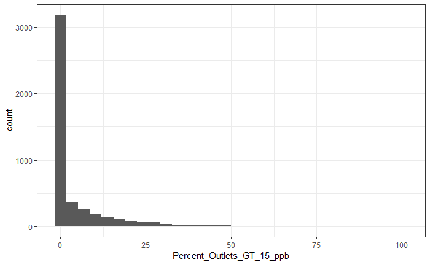

```r
Pb_data %>%
  ggplot(aes(x = Percent_Outlets_GT_15_ppb)) +
  geom_histogram() +
  theme_bw()
```

From the figure above we can see that many of the schools have ~ 0% of their faucets/fountains that exceed 15 ppb lead. We can also see that only a very small proportion of schools have more than 25% of their faucets/fountains in exceedence of 15 ppb lead.

#### Scatter plot

Now let’s make a scatter plot. Since it is reasonable to hypothesize that the wealth of a school district might influence the likelihood of lead contamination in the water, let’s create a scatter plot of the median household income (for the zip-code area of each school) vs. the percent of outlets that exceed 15 ppb lead.

You can see that we defined the mapping of each variable in the `aes()` portion of the code. We specified that we wanted to create a scatter plot by using the `geom_point()` function.

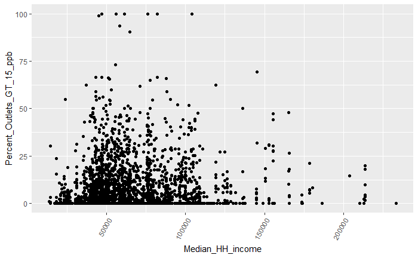

```r
Pb_data %>%
  #filter(County %in% c("Schenectady", "Albany", "Montgomery", "Rensselaer", "Kings", "Bronx")) %>%
  ggplot(aes(x = Median_HH_income, y = Percent_Outlets_GT_15_ppb)) +
  geom_point() +
  theme(axis.text.x = element_text(angle = 60, hjust = 1))
```

```r
  #facet_wrap(~ County)
```

In the above graphic each point represents an individual school. Based on the figure it does not look like there is a straightforward relationship between income level of the community around the school and the degree of lead contamination in a school’s drinking water. However, there are lots of data on the above figure and it is possible that there could be a relationship in some areas/counties but it is hidden when we look at all of the data at once.

Let’s focus on just a few counties. To do this we will `filter()` the data. The `filter()` function allows us to select subsets of the data to work with. In this case will will only select observations (schools) that are within the counties we are interested in.

In the code below we `filter()` the data based on the `County` variable. Here we only look at Schenectady, Albany, Montgomery, Rensselaer, Kings, and Bronx counties. You could change the code below to select other counties of interest if you so choose. You can also see that we used the `facet_wrap()` function. This function creates a separate figure by group (in this case we will create a separate figure for each `County`).

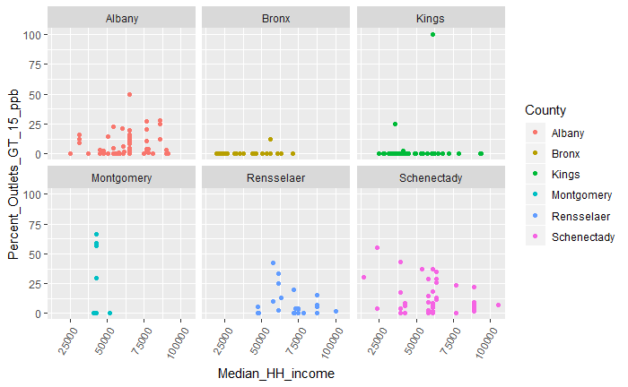

```r
Pb_data %>%
  filter(County %in% c("Schenectady", "Albany", "Montgomery", "Rensselaer", "Kings", "Bronx")) %>%
  ggplot(aes(x = Median_HH_income, y = Percent_Outlets_GT_15_ppb, color = County)) +
  geom_point() +
  theme(axis.text.x = element_text(angle = 60, hjust = 1)) +
  facet_wrap(~ County)
```

This figure is really helpful. For example, it shows us that there may be a slight negative relationship between income level and degree of contamination within Schenectady county. We also see that in Bronx county, the level of lead contamination is uniformly low across all levels of income.

### Summary tables

Summarizing your data by groups is a particularly useful exercise and often helps to reveal interesting patterns and allows for you to distill a large dataset down into a format more amenable to gaining an overall understanding of the data. For instance, you might be interested in which counties are the most (and least) heavily impacted by lead contamination in school drinking water.

In the dataset we are using each observation (row) is an individual school. It would be helpful to group the schools by county and then summarize the data by county. This way we can see the proportion of faucets/fountains that exceed 15 ppb lead for each of the counties in New York state.

We can easily do this. First we will use the `group_by()` function and specify that we want to group by the `County` variable. Once this grouping has been done, then all subsequent operations will be performed group-wise.

Next, we will use the `summarize()` function, which will allow us to specify the new variables (columns) we would like to create (based on the grouped data). We will create a column with the total number of outlets in each county `Total_Outlets` and a column with the percent of outlets that exceed 15 ppb lead in each county `Percent_Outlets_GT_15_ppb`. We’ll use the `arrange()` function to sort our summary table from highest-to-lowest county based on the percent of outlets that exceed 15 ppb.

We will assign this new dataset to an object called `County_Summary`.

```r
County_Summary <- Pb_data %>%
  group_by(County) %>%
  summarize(Total_Outlets = sum(Number_of_Outlets_LT_15_ppb, Number_of_Outlets_GT_15_ppb, na.rm = T),
            Percent_Outlets_GT_15_ppb = round(100*sum(Number_of_Outlets_GT_15_ppb, na.rm = T)/Total_Outlets, 2)) %>%
  arrange(desc(Percent_Outlets_GT_15_ppb))
  #ggplot(aes(x = reorder(County, Percent_Outlets_GT_15_ppb) , y = Percent_Outlets_GT_15_ppb)) +
  #geom_point() +
  #theme_bw() +
  #theme(axis.text.x = element_text(angle = 60, hjust = 1))
County_Summary
```

| County | Total_Outlets | Percent_Outlets_GT_15_ppb |
| --- | --- | --- |
| Schoharie | 1525 | 18.82 |
| Washington | 2983 | 18.44 |
| Sullivan | 2195 | 18.00 |
| Rockland | 7815 | 17.15 |
| Montgomery | 832 | 16.71 |
| Saratoga | 6354 | 16.64 |
| Dutchess | 6762 | 16.50 |
| Schenectady | 3070 | 16.48 |
| Seneca | 547 | 15.54 |
| Fulton | 1310 | 14.89 |

[output cut: 52 more lines]

```r
NA
```

This table is really useful. We have identified the most and least affected counties. This type of information would be helpful to the local and state government when thinking about where to focus resources for improving water quality in schools.

Now that you have your summary table saved to the data object `County_Summary` you can create figures with and perform additional analysis on this table.

```r
#ri <- counties("NY")
ri20 <- counties("NY", cb = TRUE, resolution = "20m")
plot(ri20)
plot(ri20, border = "red", add = TRUE)
```

[output not shown]

```r
a <- st_as_sf(ri20) %>%
  rename(County = NAME)
```

```r
a_test <- Pb_data %>%
  group_by(County) %>%
  summarize(Total_Outlets = sum(Number_of_Outlets_LT_15_ppb, Number_of_Outlets_GT_15_ppb, na.rm = T),
            Percent_Outlets_GT_15_ppb = 100*sum(Number_of_Outlets_GT_15_ppb, na.rm = T)/Total_Outlets,
            Latitude = first(Latitude),
            Longitude = first(Longitude),
            HH_Income = median(Median_HH_income, na.rm = T))
```

```r
a <- left_join(a, a_test)
```

```r
Pb_data %>%
  group_by(County) %>%
  summarize(Total_Outlets = sum(Number_of_Outlets_LT_15_ppb, Number_of_Outlets_GT_15_ppb, na.rm = T),
            Percent_Outlets_GT_15_ppb = 100*sum(Number_of_Outlets_GT_15_ppb, na.rm = T)/Total_Outlets,
            Latitude = first(Latitude),
            Longitude = first(Longitude)) %>%

  leaflet() %>%
  addTiles() %>%
  addMarkers(lng = ~Longitude, lat = ~Latitude)
```

```r
leaflet(a) %>%
  addPolygons(color = "#444444", weight = 1, smoothFactor = 0.5, popup = ~ paste(County, round(HH_Income,2)),
    opacity = 1.0, fillOpacity = 0.5,
    fillColor = ~colorQuantile("YlOrRd", HH_Income)(HH_Income),
    highlightOptions = highlightOptions(color = "white", weight = 2,
      bringToFront = TRUE)) %>%
  addTiles()
```

```r
leaflet(a) %>%
  addPolygons(color = "#444444", weight = 1, smoothFactor = 0.5, popup = ~ paste(County, round(Percent_Outlets_GT_15_ppb,2)),
    opacity = 1.0, fillOpacity = 0.5,
    fillColor = ~colorQuantile("YlOrRd", Percent_Outlets_GT_15_ppb)(Percent_Outlets_GT_15_ppb),
    highlightOptions = highlightOptions(color = "white", weight = 2,
      bringToFront = TRUE)) %>%
  addTiles()
```